# EDAV Fall 2019 Final Project Group 23

Shaofeng Wu, Chengyou Ju, Mingrui Liu, Yujing Song

## I. Introduction

This project is created by Shaofeng Wu (sw3428), Chengyou Ju (cj2624), Mingrui Liu (ml4404), Yujing Song (ys3251) for STAT GR5702 Final Project Group 23.

As graduate students who are actively seeking jobs and internships, we come up with the idea that we can choose a topic related to the current employment situation in New York. Therefore, after doing some research, we decide to focus on studying the latest job postings in New York. We want to see, for instance, if there is a relationship between job categories and salaries, what skills are preferred by a particular kind of jobs, or if locations matter while choosing a job.

## II. Data sources

Our data come from https://data.cityofnewyork.us/City-Government/NYC-Jobs/kpav-sd4t, which contains current job postings available on the City of New York’s official jobs site http://www.nyc.gov/html/careers/html/search/search.shtml.

Mingrui is responsible for looking for and collecting the data. Since the data can be directly exported from the website as a `.csv` file, there is no major obstacle for us when gathering the data. After downloading the data from the website, we use the built-in `read.csv` method to read and store the data as a data frame for future manipulation.

This data frame has 3040 oberservations of 28 variables. Each entry represents a job posting on the website, while the columns represent the information about each job, including Business Title, Salary Range, Job Description, etc.

The only problem about the data is that in the origin `.csv` file, there are plenty of empty entries. Therefore, when we read data from the file and store as a data frame, we fill all these blank entries with NAs.

## III. Data transformation

As mentioned in the previous section, since the dataset is stored in a neat `.csv` file, we only need to read the file using the `read.csv` method and store the data in the data frame `job`. Later, when we need some specific attributes of the job postings dataset, we can use simply `$` or pipes and the `%>%` operator to extract the columns we need.

```r
# Read data from csv file
job <- read.csv("./data/raw/NYC_jobs.csv")
# Set empty slots as NAs
job[job == ''] <- NA
```

## IV. Missing values

As mentioned above, we fill all empty slots in the original dataset with NAs, and we will keep these NAs in our data frame. Later, depends on our tasks, we will decide whether to drop the NAs or not.

## V. Results

```r
library(tm)
job_docs <- VCorpus(VectorSource(job))
# inspect(job_docs)
job_mini_req <- VCorpus(VectorSource(job$Minimum.Qual.Requirements))
# inspect(job_mini_req)
```

```r
tech_jobs <- subset(job, Job.Category == "Information Technology & Telecommunications")
job_tech_mini_req <- VCorpus(VectorSource(tech_jobs$Minimum.Qual.Requirements))
# inspect(job_tech_mini_req)
```

   Chengyou may will work on the topic of salary vs. agency, and he may also use the word cloud to explore the relationship between these two variables.

   Shaofeng will work on the data cleaning and mabipulation, and he will try to find connections among NAs or may come up with interesting topics when doing the data cleaning.

   Yujing will investigate on the topic of salary vs. regions, and she also wants to draw a map to show the salary’s region distribution.

   Mingrui will focus on the topic of salary vs. job category. Using different groups of job category to classify different levels of salaries may be something could be explored.

### 1.2 The Problem Statement

List three questions that you hope you will be able to answer from your research.

Main topic: What factors maybe influence salary?

```
a) The relationship between salary vs. regions.

b) The relationship between salary vs. job category.

c) The relationship between salary vs. agency.
```

### 2.2 Short Summary of Initial Investigations

```r
library(dplyr)
library(corpus)
library(ggplot2)
library(magrittr)
library(forcats)
library(tidyverse)
```

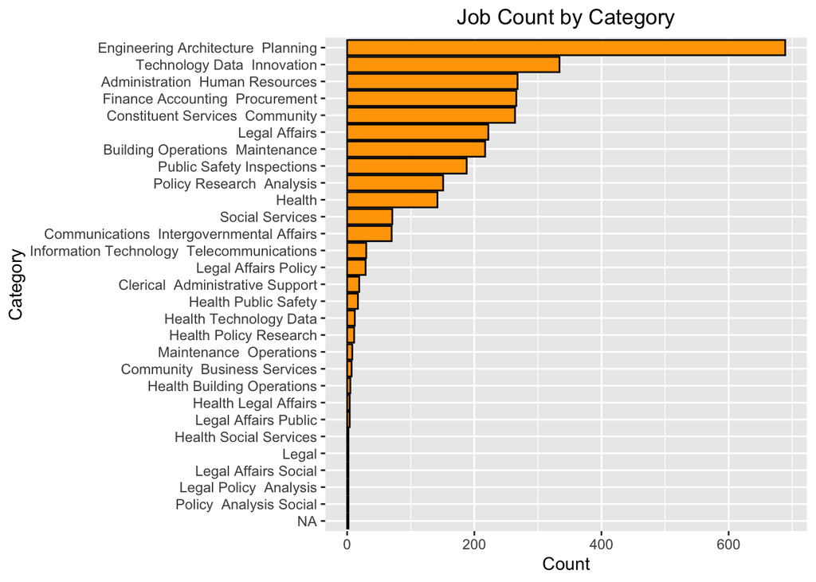

```r
categoryList <- job %>%
  select(Job.Category, Job.ID) %>%
  mutate(Job.Category = as.character(Job.Category),
         Job.Category = gsub(",|&","", Job.Category),
         Job.Category = as.vector(text_sub(Job.Category, 1 , 3, )),
         Job.Category = trimws(Job.Category,"both")) %>%
  rename(Category = Job.Category)

ggplot(categoryList, aes(fct_relevel(fct_rev(fct_infreq(fct_explicit_na(Category,'NA')))))) +
  geom_bar(color = "black", fill = "orange") +
  ggtitle("Job Count by Category") +
  labs(x = "Category", y = "Count") +
  theme(plot.title = element_text(hjust = 0.5)) +
  coord_flip()
```

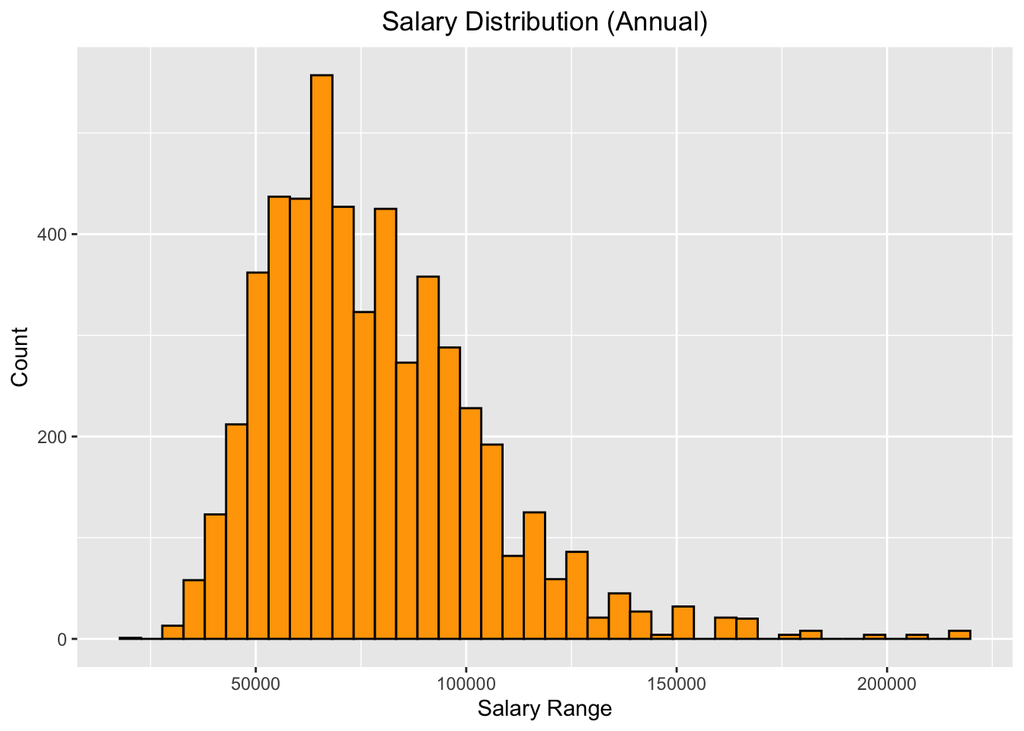

```r
job <- job%>%
  mutate(salary = Salary.Range.From+(Salary.Range.To-Salary.Range.From)/2)%>%
  merge(.,categoryList, by = "Job.ID")

Annual = job[job$Salary.Frequency=="Annual",]
ggplot(data = Annual, aes(Annual$salary)) +
  geom_histogram(bins = 40, color = "black", fill = "orange") +
  ggtitle("Salary Distribution (Annual)") +
  labs(x = "Salary Range", y = "Count") +
  theme(plot.title = element_text(hjust = 0.5))
```

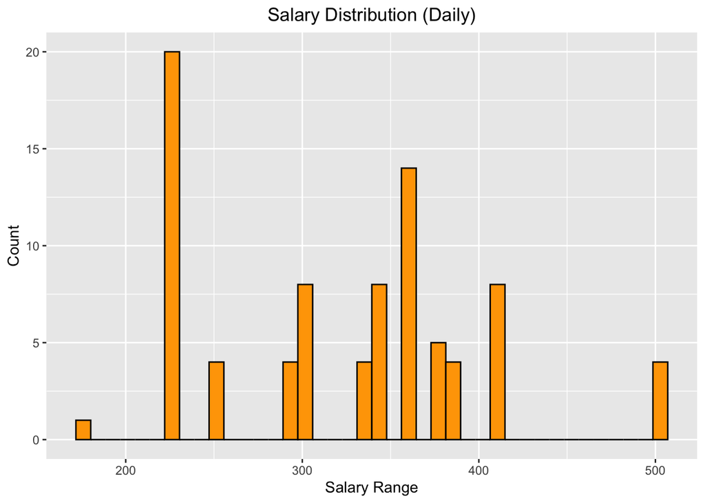

```r
Daily = job[job$Salary.Frequency=="Daily",]
ggplot(data = Daily, aes(Daily$salary)) +
  geom_histogram(bins = 40, color = "black", fill = "orange") +
  ggtitle("Salary Distribution (Daily)") +
  labs(x = "Salary Range", y = "Count") +
  theme(plot.title = element_text(hjust = 0.5))
```